# Tugas Praktikum 6 dan 7

Intan Aisa M0401241059

2026-09-30

# 1 Packages

```r
library(ggplot2)
library(tsibble)
library(tseries)
library(MASS)
library(forecast)
library(TSA)
library(TTR)
library(aTSA)
library(graphics)
library(nortest)
```

# 2 Data

Data yang digunakan adalah data kurs JISDOR harian (Agustus 2022 - Mei 2023).

```r
datakurs <- rio::import("/Users/intanaisa/Documents/Kuliah/Semester 5/Metode Peramalan Deret Waktu/Praktikum/Pertemuan 6 & 7/Data.xlsx")
head(datakurs)
```

```
##      Tanggal  Kurs
## 1 2022-08-01 14874
## 2 2022-08-02 14888
## 3 2022-08-03 14917
## 4 2022-08-04 14929
## 5 2022-08-05 14904
## 6 2022-08-08 14915
```

```r
datakurs.ts <- ts(datakurs$Kurs)
```

# 3 Eksplorasi Data

## 3.1 Plot Data

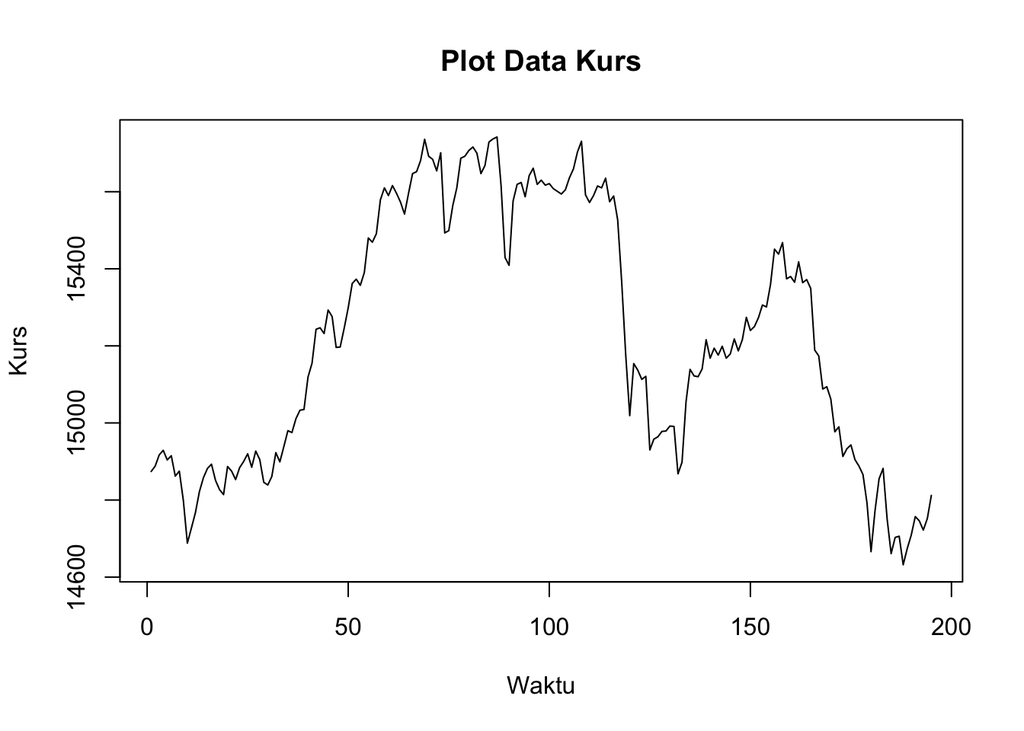

```r
plot.ts(datakurs.ts,
        lty = 1,
        xlab = "Waktu",
        ylab = "Kurs",
        main = "Plot Data Kurs")
```

Berdasarkan plot data deret waktu, terlihat bahwa data tidak bergerak di sekitar nilai tengah tertentu. Kurs naik dari sekitar 14.800 hingga mencapai puncak sekitar 15.700, bertahan di level tinggi, turun tajam, naik kembali, lalu turun hingga sekitar 14.630 mendekati akhir periode (nilai terakhir sekitar 14.800). Tidak terlihat pola musiman yang berulang. Berdasarkan pola data, pembagian data latih dan data uji ditetapkan dengan proporsi 80:20, yaitu 156 data latih dan 39 data uji.

## 3.2 Pembagian Data Latih dan Data Uji

```r
n       <- length(datakurs.ts)
n.train <- round(0.8 * n)

kurstrain <- datakurs$Kurs[1:n.train]
kurstest  <- datakurs$Kurs[(n.train + 1):n]

train.ts <- ts(kurstrain)
test.ts  <- ts(kurstest)

c(Total = n, Train = length(train.ts), Test = length(test.ts))
```

```
## Total Train  Test
##   195   156    39
```

## 3.3 Plot Data Latih

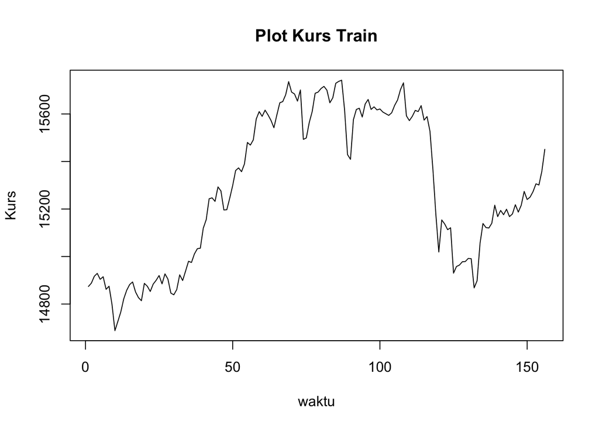

```r
plot.ts(train.ts, lty = 1, xlab = "waktu", ylab = "Kurs",
        main = "Plot Kurs Train")
```

Berdasarkan plot data latih, terlihat bahwa data memiliki tren naik pada awal periode, kemudian turun tajam, dan tidak bergerak pada nilai tengah tertentu. Hal ini mengindikasikan bahwa data tidak stasioner dalam rataan.

## 3.4 Plot Data Uji

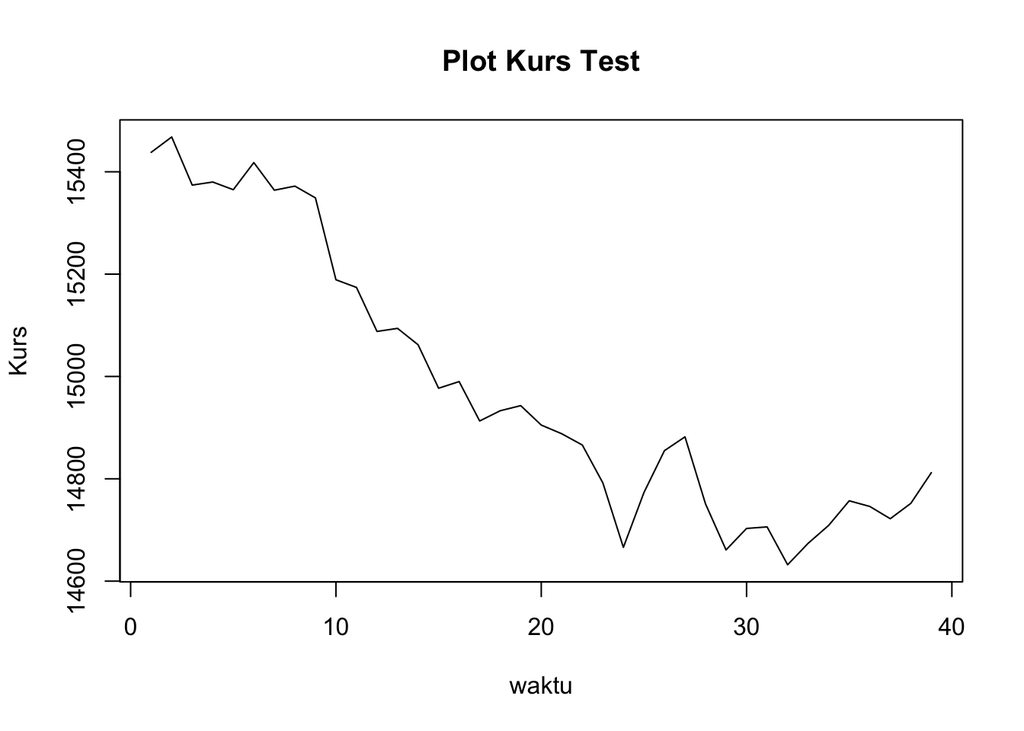

```r
plot.ts(test.ts, lty = 1, xlab = "waktu", ylab = "Kurs",
        main = "Plot Kurs Test")
```

# 4 Uji Stasioneritas Data

## 4.1 Stasioneritas dalam Ragam

### 4.1.1 Plot Box-Cox

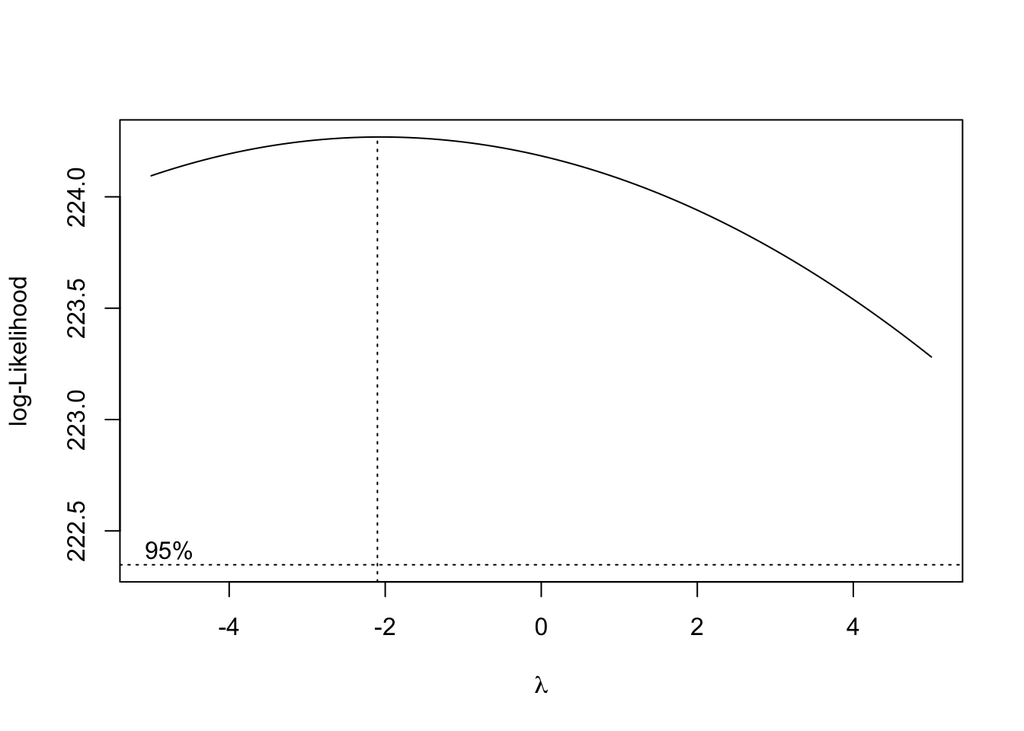

```r
index <- seq(1:length(train.ts))

# Box-Cox
bc <- boxcox(train.ts ~ index, lambda = seq(-5, 5, by = 0.1))
```

```r
# Nilai lambda optimum
lambda_opt <- bc$x[which.max(bc$y)]
lambda_opt
```

```
## [1] -2.1
```

```r
# Selang kepercayaan 95% untuk lambda
ci_lambda <- bc$x[bc$y > max(bc$y) - 0.5 * qchisq(0.95, df = 1)]

# Batas bawah dan batas atas
ci_lower <- min(ci_lambda)
ci_upper <- max(ci_lambda)

c(Batas_Bawah = ci_lower, Batas_Atas = ci_upper)
```

```
## Batas_Bawah  Batas_Atas
##          -5           5
```

Nilai $\lambda$ optimum sebesar -2,1 dengan selang kepercayaan 95% berada pada -5 hingga 5, yaitu seluruh rentang nilai $\lambda$ yang dicoba. Selang tersebut sama dengan seluruh rentang grid sehingga tidak ada bukti yang cukup untuk melakukan transformasi, maka data dianggap stasioner dalam ragam.

## 4.2 Stasioneritas dalam Rataan

### 4.2.1 Plot ACF

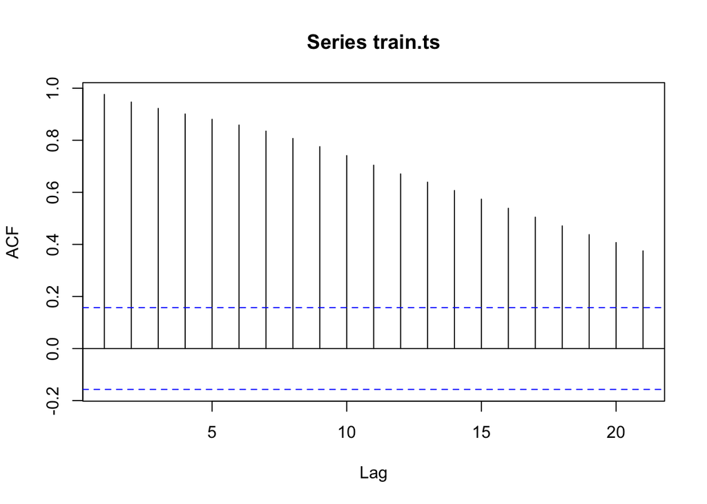

```r
acf(train.ts)
```

Berdasarkan plot ACF, terlihat bahwa nilai autokorelasi menurun secara perlahan (*tails off slowly*) dan seluruh lag yang ditampilkan berada di luar batas signifikansi. Hal ini menjadi indikasi bahwa data tidak stasioner dalam rataan.

### 4.2.2 Uji ADF

```r
tseries::adf.test(train.ts)
```

```
##
##  Augmented Dickey-Fuller Test
##
## data:  train.ts
## Dickey-Fuller = -1.384, Lag order = 5, p-value = 0.8332
## alternative hypothesis: stationary
```

$H_0$ : Data tidak stasioner dalam rataan

$H_1$ : Data stasioner dalam rataan

Berdasarkan uji ADF tersebut, didapat *p-value* sebesar 0.8332 yang lebih besar dari taraf nyata 5% sehingga tak tolak $H_0$ dan menandakan bahwa data tidak stasioner dalam rataan. Hal ini sesuai dengan hasil eksplorasi menggunakan plot deret waktu dan plot ACF, sehingga ketidakstasioneran harus ditangani terlebih dahulu.

# 5 Penanganan Ketidakstasioneran Data

## 5.1 Differencing

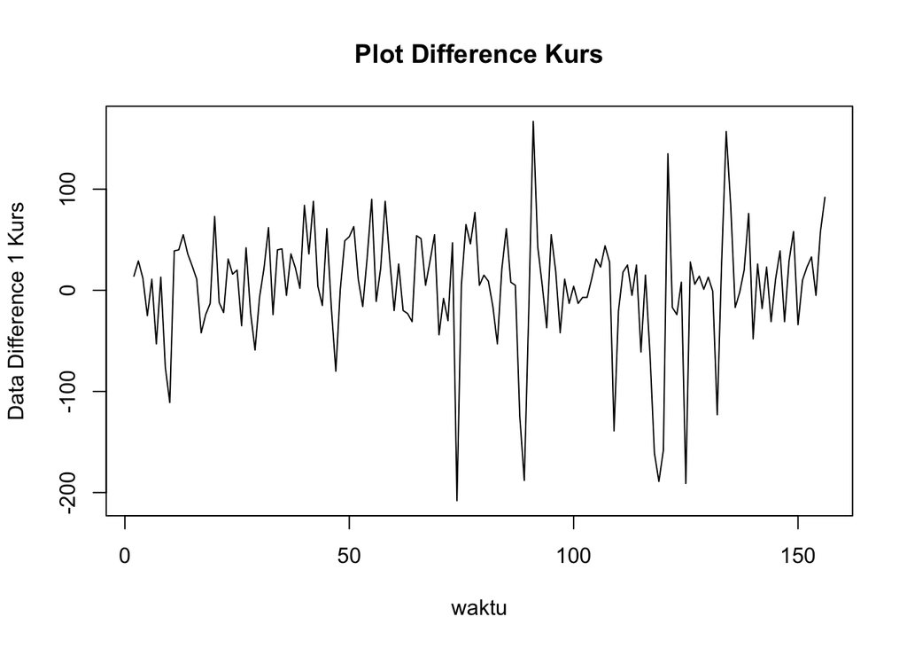

```r
# Differencing pertama
train.diff <- diff(train.ts, differences = 1)

# Plot hasil differencing
plot.ts(train.diff, lty = 1, xlab = "waktu",
        ylab = "Data Difference 1 Kurs", main = "Plot Difference Kurs")
```

Berdasarkan plot data deret waktu, terlihat bahwa data hasil differencing sudah stasioner dalam rataan, ditandai dengan data bergerak di sekitar nilai tengah tertentu (tidak terdapat tren).

### 5.1.1 Plot ACF

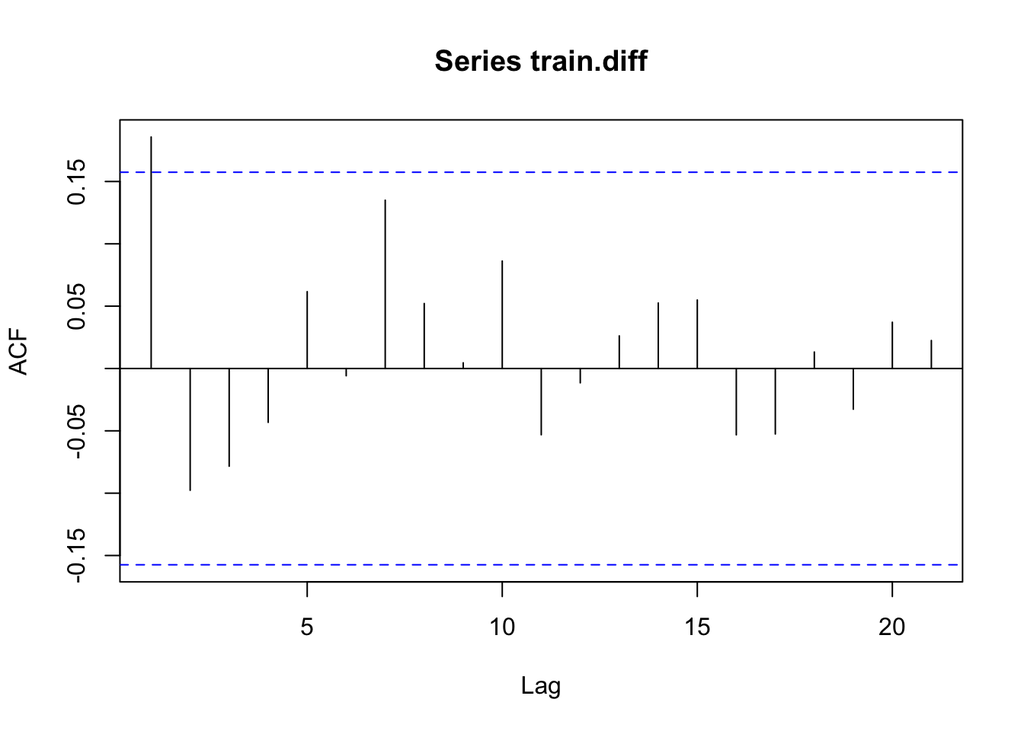

```r
acf(train.diff)
```

ACF tidak lagi menurun lambat dan hanya lag 1 yang signifikan, menandakan data sudah stasioner dalam rataan

### 5.1.2 Uji ADF

```r
tseries::adf.test(train.diff)
```

```
##
##  Augmented Dickey-Fuller Test
##
## data:  train.diff
## Dickey-Fuller = -5.0028, Lag order = 5, p-value = 0.01
## alternative hypothesis: stationary
```

$H_0$ : Data tidak stasioner dalam rataan

$H_1$ : Data stasioner dalam rataan

Berdasarkan uji ADF tersebut, didapat *p-value* ≤ 0.01 yang lebih kecil dari taraf nyata 5% sehingga tolak $H_0$. Data sudah stasioner dalam rataan setelah differencing satu kali (d = 1) dan dapat dilanjutkan ke pemodelan.

## 5.2 Pengecekan Ragam Setelah Differencing

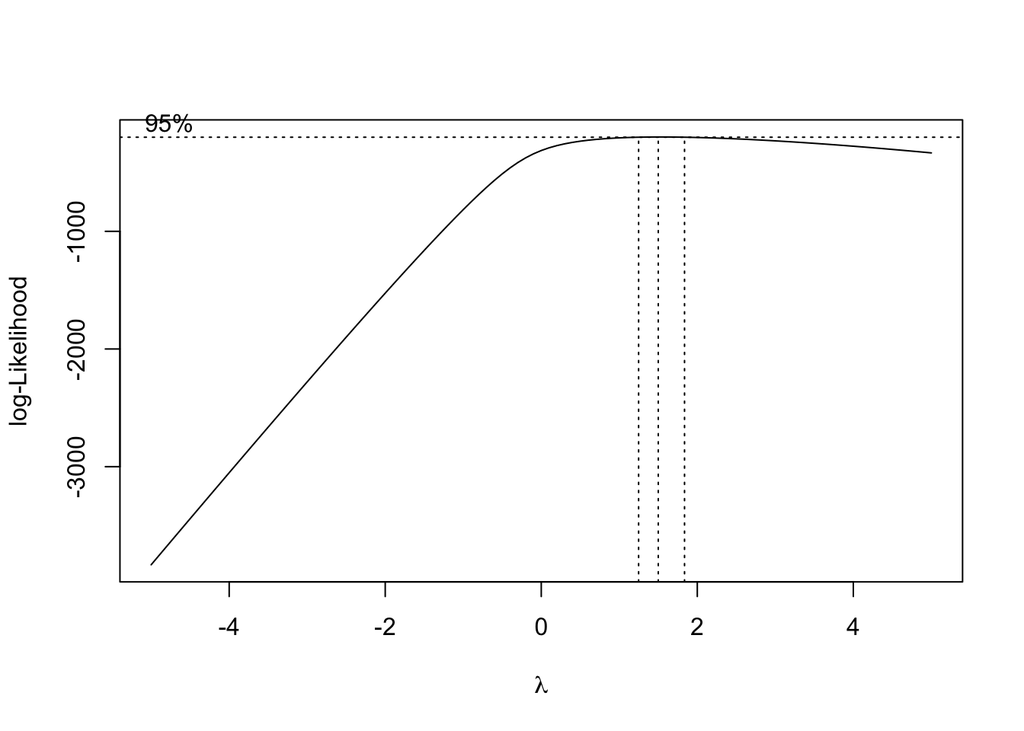

```r
index_diff <- seq(1:length(train.diff))

# Cek nilai negatif/nol; jika ada, geser data agar bernilai positif
min_val <- min(train.diff)

if (min_val <= 0) {
  shift_const <- abs(min_val) + 1
  train.diff_shifted <- train.diff + shift_const
} else {
  train.diff_shifted <- train.diff
}

# Plot Box-Cox pada data yang sudah di-shift
bc_diff <- boxcox(train.diff_shifted ~ index_diff, lambda = seq(-5, 5, by = 0.1))
```

```r
# Nilai lambda optimum
lambda_opt_diff <- bc_diff$x[which.max(bc_diff$y)]
print(paste("Lambda optimum setelah diff:", lambda_opt_diff))
```

```
## [1] "Lambda optimum setelah diff: 1.5"
```

```r
# Selang kepercayaan 95% untuk lambda
ci_lambda_diff <- bc_diff$x[bc_diff$y > max(bc_diff$y) - 0.5 * qchisq(0.95, df = 1)]

c(Batas_Bawah = min(ci_lambda_diff), Batas_Atas = max(ci_lambda_diff))
```

```
## Batas_Bawah  Batas_Atas
##         1.3         1.8
```

Pada data hasil differencing (yang telah digeser agar bernilai positif), $\lambda$ optimum sebesar 1,5 dengan selang kepercayaan 95% dari 1,3 hingga 1,8 sehingga selang tidak memuat nilai satu. Namun, pengecekan ini dilakukan terhadap data yang telah digeser dengan suatu konstanta, sehingga hasilnya bergantung pada besar konstanta tersebut dan kurang dapat diandalkan. Pada data latih (sebelum differencing) tidak ada bukti yang cukup untuk melakukan transformasi. Oleh karena itu, tidak dilakukan transformasi dan pemodelan dilanjutkan dengan data differencing tanpa transformasi.

# 6 Identifikasi Model

## 6.1 Plot ACF

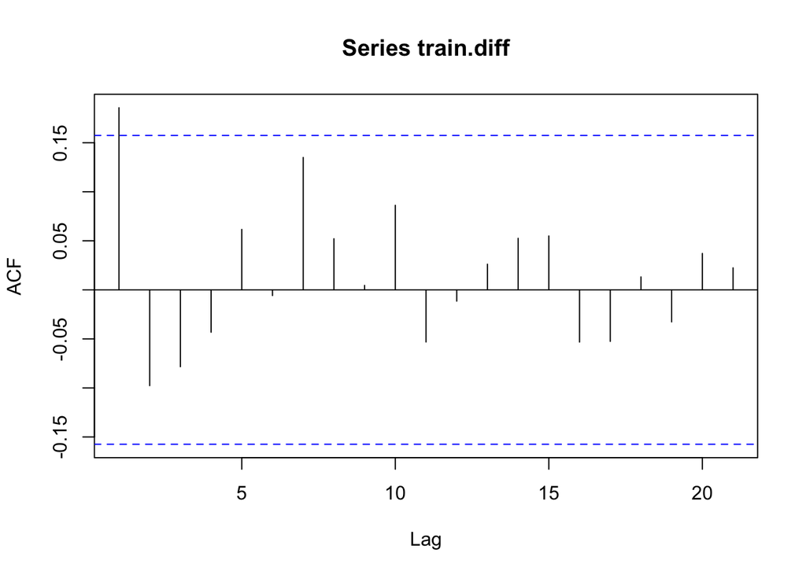

```r
acf(train.diff)
```

Plot ACF cenderung *cuts off* pada lag ke-1 (hanya lag ke-1 yang melewati batas signifikansi), sehingga jika plot PACF dianggap *tails off*, maka model tentatifnya adalah ARIMA(0,1,1).

## 6.2 Plot PACF

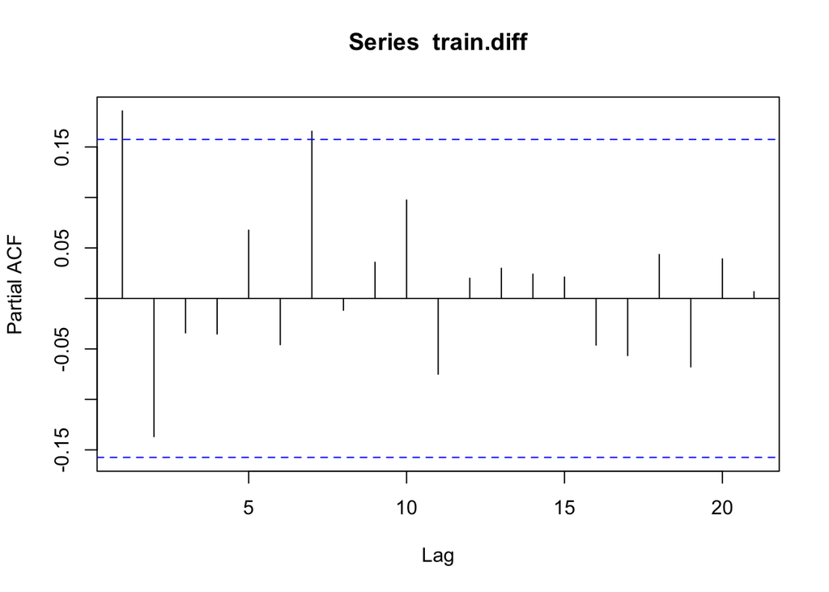

```r
pacf(train.diff)
```

Plot PACF cenderung *cuts off* pada lag ke-1, sehingga jika plot ACF dianggap *tails off*, maka model tentatifnya adalah ARIMA(1,1,0). Lag ke-7 hanya sedikit melewati batas signifikansi dan dianggap kebetulan (satu dari sekitar 20 lag), sehingga tidak diperhitungkan. Jika ACF dan PACF keduanya dianggap *tails off*, maka model yang terbentuk adalah ARIMA(1,1,1).

## 6.3 Plot EACF

```r
eacf(train.diff)
```

```
## AR/MA
##   0 1 2 3 4 5 6 7 8 9 10 11 12 13
## 0 x o o o o o o o o o o  o  o  o
## 1 x x o o o o o o o o o  o  o  o
## 2 x o o o o o o o o o o  o  o  o
## 3 x o x o o o o o o o o  o  o  o
## 4 x x x o o o o o o o o  o  o  o
## 5 x x o o x o o o o o o  o  o  o
## 6 x x o x x o o o o o o  o  o  o
## 7 o x x x x o o o o o o  o  o  o
```

Identifikasi model menggunakan EACF dilakukan dengan melihat ujung segitiga pola nol (simbol “o”). Model tentatif yang terbentuk adalah ARIMA(0,1,1) dan ARIMA(1,1,2). Selain itu, ARIMA(2,1,2) ditambahkan sebagai pembanding dengan orde yang lebih tinggi. Secara keseluruhan terdapat lima model tentatif: ARIMA(0,1,1), ARIMA(1,1,0), ARIMA(1,1,1), ARIMA(1,1,2), dan ARIMA(2,1,2).

# 7 Pendugaan Parameter Model

## 7.1 ARIMA(0,1,1)

```r
model1.da = Arima(train.diff, order = c(0,0,1), include.mean = FALSE, method = "ML")
summary(model1.da)
```

```
## Series: train.diff
## ARIMA(0,0,1) with zero mean
##
## Coefficients:
##          ma1
##       0.2347
## s.e.  0.0839
##
## sigma^2 = 3344:  log likelihood = -848.37
## AIC=1700.74   AICc=1700.81   BIC=1706.82
##
## Training set error measures:
##                   ME     RMSE      MAE      MPE     MAPE     MASE        ACF1
## Training set 3.10877 57.64008 41.61697 108.2657 131.6768 0.752585 -0.01752605
```

```r
lmtest::coeftest(model1.da)
```

```
##
## z test of coefficients:
##
##     Estimate Std. Error z value Pr(>|z|)
## ma1 0.234651   0.083856  2.7983 0.005138 **
## ---
## Signif. codes:  0 '***' 0.001 '**' 0.01 '*' 0.05 '.' 0.1 ' ' 1
```

## 7.2 ARIMA(1,1,0)

```r
model2.da = Arima(train.diff, order = c(1,0,0), include.mean = FALSE, method = "ML")
summary(model2.da)
```

```
## Series: train.diff
## ARIMA(1,0,0) with zero mean
##
## Coefficients:
##          ar1
##       0.1901
## s.e.  0.0792
##
## sigma^2 = 3376:  log likelihood = -849.1
## AIC=1702.2   AICc=1702.28   BIC=1708.29
##
## Training set error measures:
##                    ME     RMSE      MAE      MPE     MAPE      MASE       ACF1
## Training set 3.126243 57.91698 41.47072 106.8744 122.7974 0.7499402 0.02422578
```

```r
lmtest::coeftest(model2.da)
```

```
##
## z test of coefficients:
##
##     Estimate Std. Error z value Pr(>|z|)
## ar1  0.19006    0.07921  2.3994  0.01642 *
## ---
## Signif. codes:  0 '***' 0.001 '**' 0.01 '*' 0.05 '.' 0.1 ' ' 1
```

## 7.3 ARIMA(1,1,1)

```r
model3.da = Arima(train.diff, order = c(1,0,1), include.mean = FALSE, method = "ML")
summary(model3.da)
```

```
## Series: train.diff
## ARIMA(1,0,1) with zero mean
##
## Coefficients:
##           ar1     ma1
##       -0.4445  0.6527
## s.e.   0.3169  0.2727
##
## sigma^2 = 3343:  log likelihood = -847.85
## AIC=1701.69   AICc=1701.85   BIC=1710.82
##
## Training set error measures:
##                    ME     RMSE      MAE      MPE    MAPE      MASE        ACF1
## Training set 3.286902 57.44041 41.53841 105.2886 138.763 0.7511643 0.008858713
```

```r
lmtest::coeftest(model3.da)
```

```
##
## z test of coefficients:
##
##     Estimate Std. Error z value Pr(>|z|)
## ar1 -0.44454    0.31690 -1.4028   0.1607
## ma1  0.65268    0.27272  2.3932   0.0167 *
## ---
## Signif. codes:  0 '***' 0.001 '**' 0.01 '*' 0.05 '.' 0.1 ' ' 1
```

## 7.4 ARIMA(1,1,2)

```r
model4.da = Arima(train.diff, order = c(1,0,2), include.mean = FALSE, method = "ML")
summary(model4.da)
```

```
## Series: train.diff
## ARIMA(1,0,2) with zero mean
##
## Coefficients:
##          ar1      ma1      ma2
##       0.3577  -0.1473  -0.1697
## s.e.  0.4685   0.4650   0.1090
##
## sigma^2 = 3359:  log likelihood = -847.71
## AIC=1703.42   AICc=1703.69   BIC=1715.59
##
## Training set error measures:
##                    ME     RMSE      MAE      MPE   MAPE      MASE          ACF1
## Training set 3.471345 57.39292 41.37395 105.8623 133.99 0.7481902 -0.0002178809
```

```r
lmtest::coeftest(model4.da)
```

```
##
## z test of coefficients:
##
##     Estimate Std. Error z value Pr(>|z|)
## ar1  0.35767    0.46854  0.7634   0.4452
## ma1 -0.14735    0.46503 -0.3169   0.7514
## ma2 -0.16972    0.10899 -1.5572   0.1194
```

## 7.5 ARIMA(2,1,2)

```r
model5.da = Arima(train.diff, order = c(2,0,2), include.mean = FALSE, method = "ML")
summary(model5.da)
```

```
## Series: train.diff
## ARIMA(2,0,2) with zero mean
##
## Coefficients:
##          ar1      ar2      ma1     ma2
##       0.4493  -0.2283  -0.2409  0.0536
## s.e.  0.4884   0.3574   0.4997  0.3708
##
## sigma^2 = 3376:  log likelihood = -847.59
## AIC=1705.19   AICc=1705.59   BIC=1720.41
##
## Training set error measures:
##                    ME     RMSE      MAE      MPE     MAPE      MASE
## Training set 3.529472 57.34953 41.36468 108.6676 133.5189 0.7480226
##                      ACF1
## Training set -0.001167786
```

```r
lmtest::coeftest(model5.da)
```

```
##
## z test of coefficients:
##
##      Estimate Std. Error z value Pr(>|z|)
## ar1  0.449272   0.488416  0.9199   0.3576
## ar2 -0.228341   0.357370 -0.6389   0.5229
## ma1 -0.240948   0.499748 -0.4821   0.6297
## ma2  0.053607   0.370820  0.1446   0.8851
```

## 7.6 Ringkasan AIC

```r
model_tentatif <- data.frame(
  Model = c("ARIMA(0,1,1)", "ARIMA(1,1,0)", "ARIMA(1,1,1)",
            "ARIMA(1,1,2)", "ARIMA(2,1,2)"),
  AIC = c(AIC(model1.da), AIC(model2.da), AIC(model3.da),
          AIC(model4.da), AIC(model5.da)),
  BIC = c(BIC(model1.da), BIC(model2.da), BIC(model3.da),
          BIC(model4.da), BIC(model5.da))
)

model_tentatif
```

```
##          Model      AIC      BIC
## 1 ARIMA(0,1,1) 1700.735 1706.822
## 2 ARIMA(1,1,0) 1702.201 1708.288
## 3 ARIMA(1,1,1) 1701.693 1710.823
## 4 ARIMA(1,1,2) 1703.419 1715.593
## 5 ARIMA(2,1,2) 1705.189 1720.407
```

# 8 Analisis Sisaan

## 8.1 Eksplorasi Sisaan

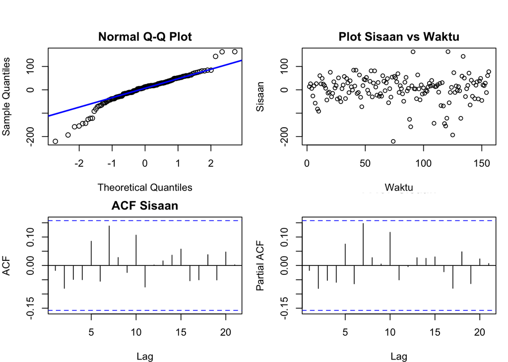

```r
sisaan.da <- model1.da$residuals

par(mfrow = c(2,2),
    mar = c(4,4,2,1),
    oma = c(0,0,2,0))

# Q-Q Plot
qqnorm(sisaan.da, main = "Normal Q-Q Plot")
qqline(sisaan.da, col = "blue", lwd = 2)

# Plot Sisaan vs Waktu
plot(sisaan.da, type = "p",
     main = "Plot Sisaan vs Waktu",
     xlab = "Waktu", ylab = "Sisaan")

# ACF
acf(sisaan.da, main = "ACF Sisaan")

# PACF
pacf(sisaan.da, main = "PACF Sisaan")
```

Berdasarkan plot kuantil-kuantil normal, sebagian besar titik berada di sekitar garis 45°, tetapi terdapat penyimpangan pada kedua ekor sehingga sisaan tidak sepenuhnya menyebar normal. Pada plot sisaan terhadap waktu, sisaan bergerak di sekitar nol, namun terdapat beberapa pencilan (sekitar -210 dan +140) sehingga lebar pita sebaran sisaan tampak kurang seragam. Plot ACF dan PACF sisaan tidak memiliki spike yang melewati batas signifikansi sehingga sisaan dapat dianggap saling bebas. Kondisi ini diuji lebih lanjut dengan uji formal.

## 8.2 Uji Formal

### 8.2.1 Normalitas Sisaan

```r
nortest::lillie.test(sisaan.da)
```

```
##
##  Lilliefors (Kolmogorov-Smirnov) normality test
##
## data:  sisaan.da
## D = 0.10608, p-value = 0.0002083
```

$H_0$ : Sisaan menyebar normal

$H_1$ : Sisaan tidak menyebar normal

Didapat *p-value* sebesar 0.0002083 yang lebih kecil dari taraf nyata 5% sehingga tolak $H_0$ dan sisaan tidak menyebar normal. Hal ini sesuai dengan hasil eksplorasi yang menunjukkan penyimpangan titik pada kedua ekor plot kuantil-kuantil normal.

### 8.2.2 Kebebasan Sisaan

```r
Box.test(sisaan.da, lag = 10, type = "Ljung-Box", fitdf = 1)
```

```
##
##  Box-Ljung test
##
## data:  sisaan.da
## X-squared = 8.8384, df = 9, p-value = 0.4523
```

$H_0$ : Sisaan saling bebas

$H_1$ : Sisaan tidak saling bebas

Didapat *p-value* sebesar 0.4523 (Ljung-Box lag 10) yang lebih besar dari taraf nyata 5% sehingga gagal tolak $H_0$ dan sisaan saling bebas (tidak ada autokorelasi). Hal ini sesuai dengan hasil eksplorasi menggunakan plot ACF dan PACF sisaan.

### 8.2.3 Kehomogenan Ragam Sisaan

```r
Box.test((sisaan.da)^2, lag = 10, type = "Ljung-Box")
```

```
##
##  Box-Ljung test
##
## data:  (sisaan.da)^2
## X-squared = 9.4438, df = 10, p-value = 0.4906
```

$H_0$ : Ragam sisaan homogen

$H_1$ : Ragam sisaan tidak homogen

Didapat *p-value* sebesar 0.4906 (Ljung-Box lag 10) yang lebih besar dari taraf nyata 5% sehingga gagal tolak $H_0$ dan ragam sisaan homogen (tidak terdapat efek ARCH hingga lag ke-10). Meskipun plot sisaan menunjukkan beberapa pencilan, uji formal tidak mendeteksi adanya heterogenitas ragam.

### 8.2.4 Nilai Tengah Sisaan

```r
t.test(sisaan.da, mu = 0, conf.level = 0.95)
```

```
##
##  One Sample t-test
##
## data:  sisaan.da
## t = 0.67028, df = 154, p-value = 0.5037
## alternative hypothesis: true mean is not equal to 0
## 95 percent confidence interval:
##  -6.053563 12.271103
## sample estimates:
## mean of x
##   3.10877
```

$H_0$ : Nilai tengah sisaan sama dengan 0

$H_1$ : Nilai tengah sisaan tidak sama dengan 0

Didapat *p-value* sebesar 0.5037 yang lebih besar dari taraf nyata 5% sehingga gagal tolak $H_0$ dan nilai tengah sisaan sama dengan nol.

# 9 Overfitting

Overfitting dilakukan dengan menaikkan orde AR(p) dan MA(q) dari model terpilih. Untuk ARIMA(0,1,1), kandidat overfitting adalah ARIMA(1,1,1) dan ARIMA(0,1,2).

```r
model.over1 = Arima(train.diff, order = c(1,0,1), include.mean = FALSE, method = "ML")   # ARIMA(1,1,1)
summary(model.over1)
```

```
## Series: train.diff
## ARIMA(1,0,1) with zero mean
##
## Coefficients:
##           ar1     ma1
##       -0.4445  0.6527
## s.e.   0.3169  0.2727
##
## sigma^2 = 3343:  log likelihood = -847.85
## AIC=1701.69   AICc=1701.85   BIC=1710.82
##
## Training set error measures:
##                    ME     RMSE      MAE      MPE    MAPE      MASE        ACF1
## Training set 3.286902 57.44041 41.53841 105.2886 138.763 0.7511643 0.008858713
```

```r
lmtest::coeftest(model.over1)
```

```
##
## z test of coefficients:
##
##     Estimate Std. Error z value Pr(>|z|)
## ar1 -0.44454    0.31690 -1.4028   0.1607
## ma1  0.65268    0.27272  2.3932   0.0167 *
## ---
## Signif. codes:  0 '***' 0.001 '**' 0.01 '*' 0.05 '.' 0.1 ' ' 1
```

```r
model.over2 = Arima(train.diff, order = c(0,0,2), include.mean = FALSE, method = "ML")   # ARIMA(0,1,2)
summary(model.over2)
```

```
## Series: train.diff
## ARIMA(0,0,2) with zero mean
##
## Coefficients:
##          ma1      ma2
##       0.2103  -0.0932
## s.e.  0.0817   0.0916
##
## sigma^2 = 3343:  log likelihood = -847.86
## AIC=1701.71   AICc=1701.87   BIC=1710.84
##
## Training set error measures:
##                    ME     RMSE      MAE      MPE     MAPE      MASE        ACF1
## Training set 3.349798 57.44717 41.42106 105.5778 132.8329 0.7490422 0.001498456
```

```r
lmtest::coeftest(model.over2)
```

```
##
## z test of coefficients:
##
##      Estimate Std. Error z value Pr(>|z|)
## ma1  0.210292   0.081704  2.5738  0.01006 *
## ma2 -0.093190   0.091560 -1.0178  0.30877
## ---
## Signif. codes:  0 '***' 0.001 '**' 0.01 '*' 0.05 '.' 0.1 ' ' 1
```

```r
overfitting <- data.frame(
  Model = c("ARIMA(0,1,1)", "ARIMA(1,1,1)", "ARIMA(0,1,2)"),
  AIC   = c(AIC(model1.da), AIC(model.over1), AIC(model.over2)),
  BIC   = c(BIC(model1.da), BIC(model.over1), BIC(model.over2))
)
overfitting
```

```
##          Model      AIC      BIC
## 1 ARIMA(0,1,1) 1700.735 1706.822
## 2 ARIMA(1,1,1) 1701.693 1710.823
## 3 ARIMA(0,1,2) 1701.712 1710.842
```

Berdasarkan hasil di atas, kedua model overfitting memiliki AIC dan BIC yang lebih besar dibandingkan ARIMA(0,1,1) (AIC ARIMA(0,1,1) = 1700,74, ARIMA(1,1,1) = 1701,69, dan ARIMA(0,1,2) = 1701,71). Selain itu, parameter tambahan tidak signifikan, yaitu AR(1) pada ARIMA(1,1,1) (p-value 0,161) dan MA(2) pada ARIMA(0,1,2) (p-value 0,309). Oleh karena itu, model yang digunakan untuk peramalan adalah ARIMA(0,1,1).

# 10 Peramalan

```r
ramalan.da <- forecast::forecast(model1.da, h = length(test.ts))
ramalan.da
```

```
##     Point Forecast     Lo 80    Hi 80      Lo 95    Hi 95
## 157       18.24263 -55.86555 92.35081  -95.09605 131.5813
## 158        0.00000 -76.12109 76.12109 -116.41716 116.4172
## 159        0.00000 -76.12109 76.12109 -116.41716 116.4172
## 160        0.00000 -76.12109 76.12109 -116.41716 116.4172
## 161        0.00000 -76.12109 76.12109 -116.41716 116.4172
## 162        0.00000 -76.12109 76.12109 -116.41716 116.4172
## 163        0.00000 -76.12109 76.12109 -116.41716 116.4172
## 164        0.00000 -76.12109 76.12109 -116.41716 116.4172
## 165        0.00000 -76.12109 76.12109 -116.41716 116.4172
## 166        0.00000 -76.12109 76.12109 -116.41716 116.4172
## 167        0.00000 -76.12109 76.12109 -116.41716 116.4172
## 168        0.00000 -76.12109 76.12109 -116.41716 116.4172
## 169        0.00000 -76.12109 76.12109 -116.41716 116.4172
## 170        0.00000 -76.12109 76.12109 -116.41716 116.4172
```

[output cut: 25 more lines]

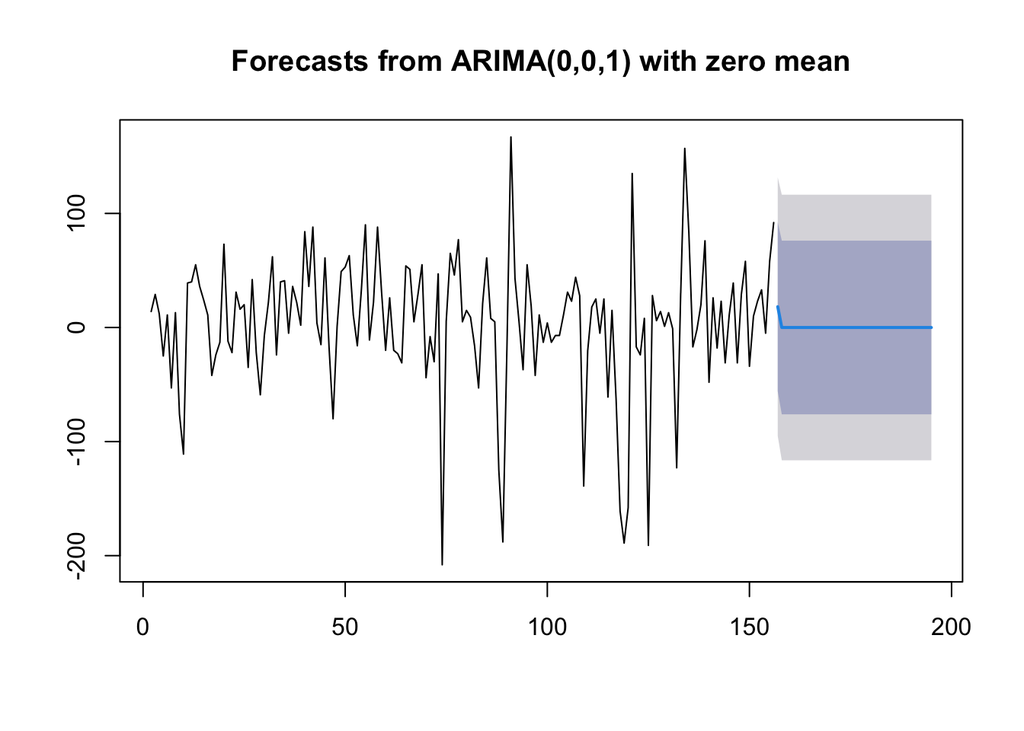

```r
data.ramalan.da <- ramalan.da$mean
plot(ramalan.da)
```

Hasil peramalan di atas masih berada pada skala data hasil differencing. Nilai ramalan hanya berubah pada periode pertama (18,24), kemudian bernilai nol untuk periode berikutnya, karena model MA(1) hanya memiliki memori satu periode dan model tidak memuat drift. Ramalan perlu dikembalikan ke skala awal dengan *inverse differencing*.

```r
# Inverse differencing
pt_akhir_train <- tail(train.ts, 1)

forecast.inv <- diffinv(data.ramalan.da, differences = 1, xi = pt_akhir_train)
hasil <- forecast.inv[-1]     # buang titik awal (nilai terakhir train)

# Bandingkan aktual vs forecast
perbandingan.da <- cbind(
  Aktual   = as.numeric(test.ts),
  Forecast = hasil
)

print(head(perbandingan.da, 10))
```

```
##       Aktual Forecast
##  [1,]  15438 15469.24
##  [2,]  15468 15469.24
##  [3,]  15374 15469.24
##  [4,]  15380 15469.24
##  [5,]  15365 15469.24
##  [6,]  15418 15469.24
##  [7,]  15364 15469.24
##  [8,]  15372 15469.24
##  [9,]  15349 15469.24
## [10,]  15189 15469.24
```

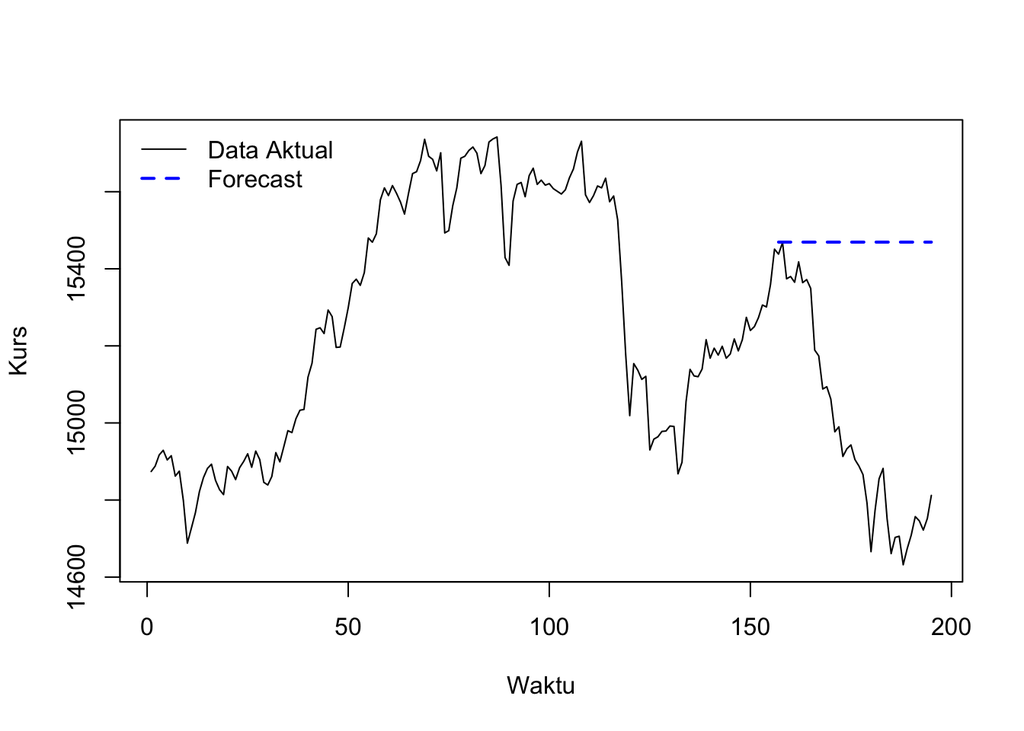

```r
# Plot data aktual dan forecast
ts.plot(datakurs.ts, col = "black", lty = 1,
        xlab = "Waktu", ylab = "Kurs")

lines((n.train + 1):(n.train + length(hasil)), hasil,
      col = "blue", lty = 2, lwd = 2)

legend("topleft",
       legend = c("Data Aktual", "Forecast"),
       col = c("black", "blue"),
       lty = c(1, 2), lwd = c(1, 2), bty = "n")
```

Berdasarkan plot terlihat bahwa ramalan ARIMA(0,1,1) datar di sekitar 15.469 sepanjang periode uji, sedangkan data aktual pada periode uji justru menurun hingga sekitar 14.630. Ketepatan ramalan diukur secara kuantitatif pada bagian evaluasi berikut.

# 11 Evaluasi Model

Evaluasi dilakukan dengan membandingkan hasil ramalan dengan data uji (skala kurs asli) menggunakan beberapa metrik ukuran kesalahan.

```r
aktual   <- as.numeric(test.ts)
ramalan  <- as.numeric(hasil)
galat    <- aktual - ramalan

# Metrik evaluasi
ME    <- mean(galat)
MSE   <- mean(galat^2)
RMSE  <- sqrt(MSE)
MAE   <- mean(abs(galat))
MAPE  <- mean(abs(galat / aktual)) * 100
SMAPE <- mean(2 * abs(galat) / (abs(aktual) + abs(ramalan))) * 100

evaluasi <- data.frame(
  Metrik = c("ME", "MSE", "RMSE", "MAE", "MAPE (%)", "SMAPE (%)"),
  Nilai  = round(c(ME, MSE, RMSE, MAE, MAPE, SMAPE), 4)
)
evaluasi
```

```
##      Metrik       Nilai
## 1        ME   -491.2170
## 2       MSE 311442.0025
## 3      RMSE    558.0699
## 4       MAE    491.2170
## 5  MAPE (%)      3.3116
## 6 SMAPE (%)      3.2420
```

```r
accuracy(ramalan, aktual)
```

```
##                ME     RMSE     MAE       MPE     MAPE
## Test set -491.217 558.0699 491.217 -3.311586 3.311586
```

```r
naive <- rep(as.numeric(tail(train.ts, 1)), length(test.ts))
accuracy(naive, aktual)
```

```
##                 ME     RMSE      MAE       MPE     MAPE
## Test set -472.9744 542.0817 473.8462 -3.189752 3.195388
```

Berdasarkan hasil evaluasi, nilai RMSE sebesar 558,07, MAE sebesar 491,22, dan MAPE sebesar 3,31%. Nilai ME sebesar -491,22 yang sama dengan MAE menunjukkan bahwa ramalan selalu lebih tinggi dari data aktual. Secara persentase galat relatif kecil (MAPE 3,31%) karena skala kurs yang besar, tetapi model gagal menangkap arah pergerakan data uji. Sebagai pembanding, peramalan naive (nilai terakhir data latih diulang) menghasilkan RMSE 542,08, MAE 473,85, dan MAPE 3,20%, yang sedikit lebih baik dibandingkan ARIMA(0,1,1). Hal ini wajar karena ramalan ARIMA(0,1,1) hampir datar sehingga menyerupai random walk dengan koreksi kecil pada periode pertama. Dengan demikian, model ARIMA(0,1,1) tidak memberikan perbaikan dibandingkan metode naive dan kurang baik untuk peramalan jangka panjang pada data ini karena tidak dapat memprediksi titik balik.

# 12 Kesimpulan

Data kurs JISDOR tidak stasioner dalam rataan (ADF p-value 0,8332) sehingga dilakukan differencing satu kali, setelah itu data stasioner (ADF p-value ≤ 0,01). Model terbaik yang terpilih adalah ARIMA(0,1,1) tanpa drift karena memiliki AIC (1700,74) dan BIC (1706,82) terkecil, parameter MA(1) signifikan (p-value 0,0051), dan model overfitting (ARIMA(1,1,1) dan ARIMA(0,1,2)) tidak lebih baik. Asumsi kebebasan sisaan (p-value 0,4523), kehomogenan ragam (p-value 0,4906), dan nilai tengah sisaan sama dengan nol (p-value 0,5037) terpenuhi, tetapi asumsi normalitas tidak terpenuhi (Lilliefors p-value 0,0002) sehingga selang kepercayaan ramalan perlu ditafsirkan dengan hati-hati. Pada data uji, model menghasilkan RMSE 558,07, MAE 491,22, dan MAPE 3,31%. Ramalan datar di sekitar 15.469 sementara data aktual menurun, dan hasilnya tidak lebih baik dari metode naive (RMSE 542,08; MAE 473,85; MAPE 3,20%), sehingga model kurang mampu meramalkan pergerakan kurs pada periode uji.